# Intro to dplyr - Lab

## Exercise:

Go back to our flights exercise data. Consider flights from JFK to SEA. What was the average, min, and max air time of those flights? Use pipes to answer this question in one statement (without showing any other data)!

```r
library(nycflights13)
library(dplyr)

jfk_to_sea_stats <- flights %>%
  filter(origin == "JFK", dest == "SEA") %>%
  summarise(
    avg_air_time = mean(air_time, na.rm = TRUE),
    min_air_time = min(air_time, na.rm = TRUE),
    max_air_time = max(air_time, na.rm = TRUE)
  )

jfk_to_sea_stats
```

```
## # A tibble: 1 × 3
##   avg_air_time min_air_time max_air_time
##          <dbl>        <dbl>        <dbl>
## 1         329.          275          389
```

Consider flights coming into Houston (HOU and IAH). What is the mean arrival delay by departure airport?

```r
library(nycflights13)
library(dplyr)

houston_arrival_delays <- flights %>%
  filter(dest %in% c("HOU", "IAH")) %>%
  group_by(origin) %>%
  summarise(mean_arr_delay = mean(arr_delay, na.rm = TRUE))

houston_arrival_delays
```

```
## # A tibble: 3 × 2
##   origin mean_arr_delay
##   <chr>           <dbl>
## 1 EWR              6.23
## 2 JFK             10.3
## 3 LGA              1.37
```

Getting ready for next class: Create a list of all the different values for the destination airport.

```r
library(nycflights13)
library(dplyr)

destination_airports <- flights %>%
  distinct(dest) %>%
  arrange(dest)

destination_airports
```

```
## # A tibble: 105 × 1
##    dest
##    <chr>
##  1 ABQ
##  2 ACK
##  3 ALB
##  4 ANC
##  5 ATL
##  6 AUS
##  7 AVL
##  8 BDL
##  9 BGR
## 10 BHM
## # ℹ 95 more rows
```

Hmm… I don’t know about you, but it sure does seem like there are some values here I don’t recognize!

## Lab for the day:

In the package `dplyr` there is a dataset called `starwars`.

```r
glimpse(starwars)
```

```
## Rows: 87
## Columns: 14
## $ name       <chr> "Luke Skywalker", "C-3PO", "R2-D2", "Darth Vader", "Leia Or…
## $ height     <int> 172, 167, 96, 202, 150, 178, 165, 97, 183, 182, 188, 180, 2…
## $ mass       <dbl> 77.0, 75.0, 32.0, 136.0, 49.0, 120.0, 75.0, 32.0, 84.0, 77.…
## $ hair_color <chr> "blond", NA, NA, "none", "brown", "brown, grey", "brown", N…
## $ skin_color <chr> "fair", "gold", "white, blue", "white", "light", "light", "…
## $ eye_color  <chr> "blue", "yellow", "red", "yellow", "brown", "blue", "blue",…
## $ birth_year <dbl> 19.0, 112.0, 33.0, 41.9, 19.0, 52.0, 47.0, NA, 24.0, 57.0, …
## $ sex        <chr> "male", "none", "none", "male", "female", "male", "female",…
## $ gender     <chr> "masculine", "masculine", "masculine", "masculine", "femini…
## $ homeworld  <chr> "Tatooine", "Tatooine", "Naboo", "Tatooine", "Alderaan", "T…
## $ species    <chr> "Human", "Droid", "Droid", "Human", "Human", "Human", "Huma…
## $ films      <list> <"A New Hope", "The Empire Strikes Back", "Return of the J…
## $ vehicles   <list> <"Snowspeeder", "Imperial Speeder Bike">, <>, <>, <>, "Imp…
## $ starships  <list> <"X-wing", "Imperial shuttle">, <>, <>, "TIE Advanced x1",…
```

We’re going to use this to practice some data wrangling with `dplyr`.

First, we filter by species to only see the humans, and use that subset to plot a scatter plot of their height and mass.

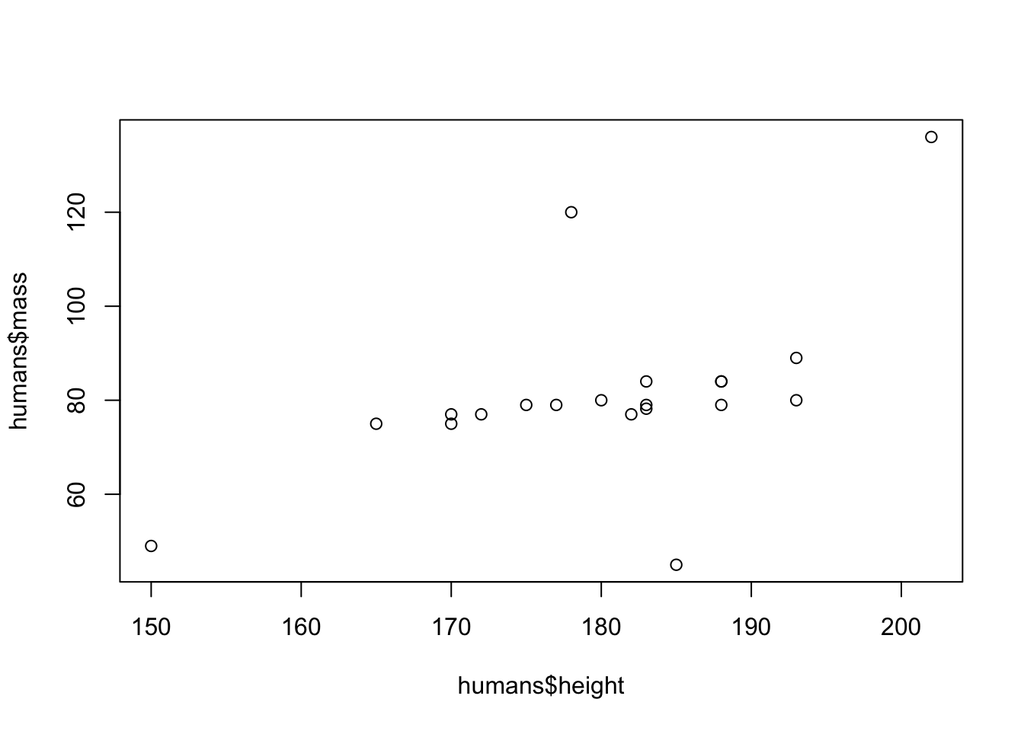

```r
humans <- starwars %>% filter(species == "Human")
plot(humans$height, humans$mass)
```

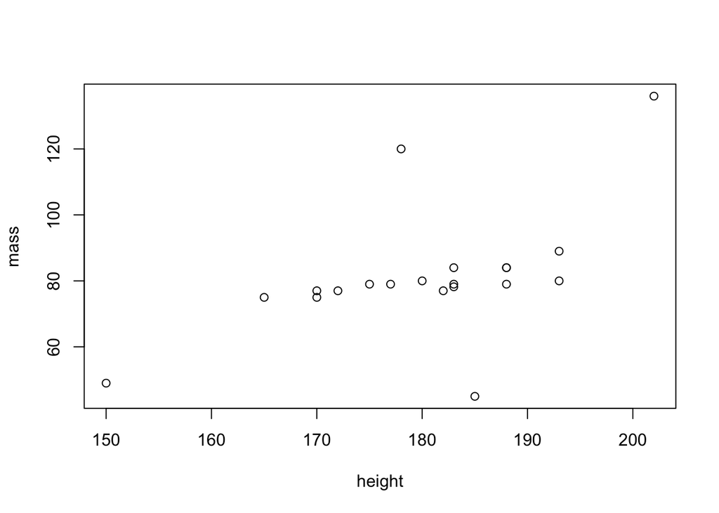

```r
starwars %>% filter(species == "Human") %>% plot(mass ~ height, data = .)
```

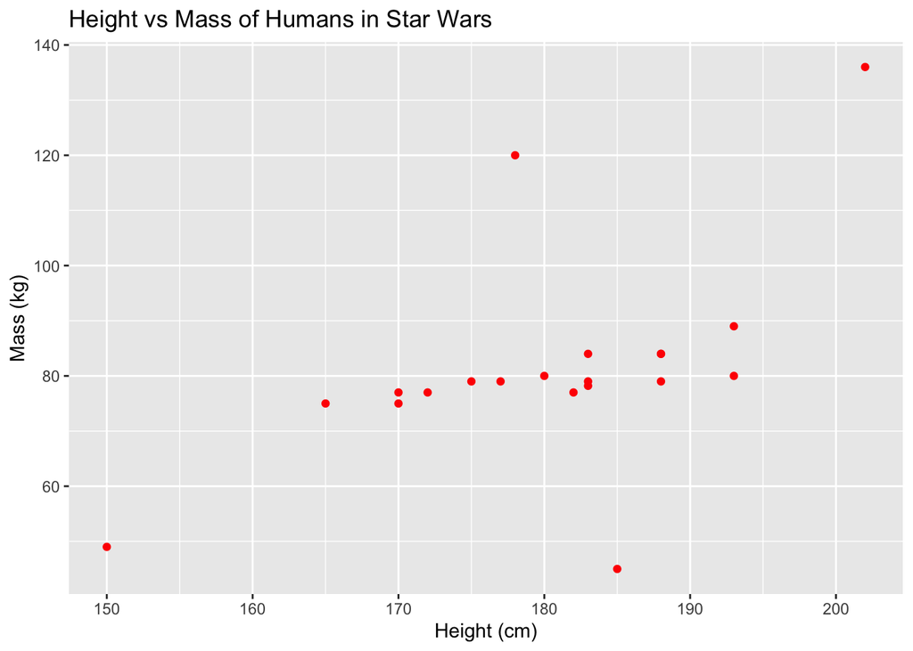

```r
ggplot(humans, aes(x = height, y = mass)) +
  geom_point(color = "red") +
  labs(title = "Height vs Mass of Humans in Star Wars",
       x = "Height (cm)",
       y = "Mass (kg)")
```

How many characters are from each planet?

```r
library(dplyr)

planet_counts <- starwars %>%
  group_by(homeworld) %>%
  summarise(character_count = n()) %>%
  arrange(desc(character_count))

planet_counts
```

```
## # A tibble: 49 × 2
##    homeworld character_count
##    <chr>               <int>
##  1 Naboo                  11
##  2 Tatooine               10
##  3 <NA>                   10
##  4 Alderaan                3
##  5 Coruscant               3
##  6 Kamino                  3
##  7 Corellia                2
##  8 Kashyyyk                2
##  9 Mirial                  2
## 10 Ryloth                  2
## # ℹ 39 more rows
```

If you wanted to arrange this in descending order, what would you add to the pipe?

```r
planet_counts <- starwars %>%
  filter(!is.na(homeworld)) %>%
  group_by(homeworld) %>%
  summarise(character_count = n()) %>%
  arrange(desc(character_count))

planet_counts
```

```
## # A tibble: 48 × 2
##    homeworld   character_count
##    <chr>                 <int>
##  1 Naboo                    11
##  2 Tatooine                 10
##  3 Alderaan                  3
##  4 Coruscant                 3
##  5 Kamino                    3
##  6 Corellia                  2
##  7 Kashyyyk                  2
##  8 Mirial                    2
##  9 Ryloth                    2
## 10 Aleen Minor               1
## # ℹ 38 more rows
```

Find the average height for each eye color. You might find some of the answers to be strange, but keep going!

```r
library(dplyr)

eye_color_avg_height <- starwars %>%
  group_by(eye_color) %>%
  summarise(avg_height = mean(height, na.rm = TRUE)) %>%
  arrange(desc(avg_height))

eye_color_avg_height
```

```
## # A tibble: 15 × 2
##    eye_color     avg_height
##    <chr>              <dbl>
##  1 green, yellow       216
##  2 gold                191
##  3 black               185
##  4 blue                182.
##  5 blue-gray           182
##  6 orange              180.
##  7 pink                180
##  8 white               178
##  9 yellow              178.
## 10 hazel               174
## 11 brown               167.
## 12 red                 155.
## 13 unknown             136
## 14 red, blue            96
## 15 dark                NaN
```

```r
library(dplyr)

brown_eyes <- starwars %>%
  filter(eye_color == "brown") %>%
  select(name, height)

brown_eyes
```

```
## # A tibble: 21 × 2
##    name                  height
##    <chr>                  <int>
##  1 Leia Organa              150
##  2 Biggs Darklighter        183
##  3 Han Solo                 180
##  4 Yoda                      66
##  5 Boba Fett                183
##  6 Lando Calrissian         177
##  7 Arvel Crynyd              NA
##  8 Wicket Systri Warrick     88
##  9 Padmé Amidala            185
## 10 Quarsh Panaka            183
## # ℹ 11 more rows
```

Okay, so we have missing data here. Try summarising with `na.omit(height)` instead of just `height` or adding `na.rm = T` to the mean function inside summarize.

```r
eye_color_avg_height <- starwars %>%
  filter(!is.na(height)) %>%
  group_by(eye_color) %>%
  summarise(avg_height = mean(height)) %>%
  arrange(desc(avg_height))

eye_color_avg_height
```

```
## # A tibble: 14 × 2
##    eye_color     avg_height
##    <chr>              <dbl>
##  1 green, yellow       216
##  2 gold                191
##  3 black               185
##  4 blue                182.
##  5 blue-gray           182
##  6 orange              180.
##  7 pink                180
##  8 white               178
##  9 yellow              178.
## 10 hazel               174
## 11 brown               167.
## 12 red                 155.
## 13 unknown             136
## 14 red, blue            96
```

So, who is the tallest male? How many blue eyed women are there? How many genders are there? Answer these questions and spend some time asking and answering some of your own.

```r
library(dplyr)

tallest_male <- starwars %>%
  filter(gender == "masculine", !is.na(height)) %>%
  filter(height == max(height)) %>%
  select(name, height, species, homeworld)

tallest_male
```

```
## # A tibble: 1 × 4
##   name        height species  homeworld
##   <chr>        <int> <chr>    <chr>
## 1 Yarael Poof    264 Quermian Quermia
```

```r
# Blue-eyed women
blue_eyed_women_count <- starwars %>%
  filter(gender == "feminine", eye_color == "blue") %>%
  summarise(count = n())

blue_eyed_women_count
```

```
## # A tibble: 1 × 1
##   count
##   <int>
## 1     6
```

```r
# Genders
unique_genders <- starwars %>%
  distinct(gender)

unique_genders
```

```
## # A tibble: 3 × 1
##   gender
##   <chr>
## 1 masculine
## 2 feminine
## 3 <NA>
```